# Predicting the Usefulness of Yelp Reviews

David Bolin

March 25, 2016

In this project I take the Yelp dataset from https://www.yelp.com/dataset_challenge and attempt to predict the usefulness of the reviews, as measured by user votes, from other features of the reviews. It turns out that most of the potential predictive power can be achieved by a simple linear model based on the length of the review, or on the length of the review together with the number of stars given. It is possible, however, to produce an improved model by including features of the text of the review.

I converted the dataset files to .csv using Paul Butler’s Python code at https://gist.github.com/paulgb/5265767. Due to the memory limits of my PC, I took five percent (111,260 reviews) of the set of reviews as a training set, and another five percent as a test set.

The distributions of the votes and of the number of words in a review are skewed, and after considering various possibilities, I decided to use a log transformation on both. The log transform of the length was then scaled to have a mean of 0 and a standard deviation of 1.

If we plot the number of words in a review against usefulness, we can see that generally a greater number of words predicts greater utility, but there seems to be some non-linearity at the end of the scale: if the review is too long, perhaps people don’t bother to read it, or in any case the marginal benefit of the length diminishes.

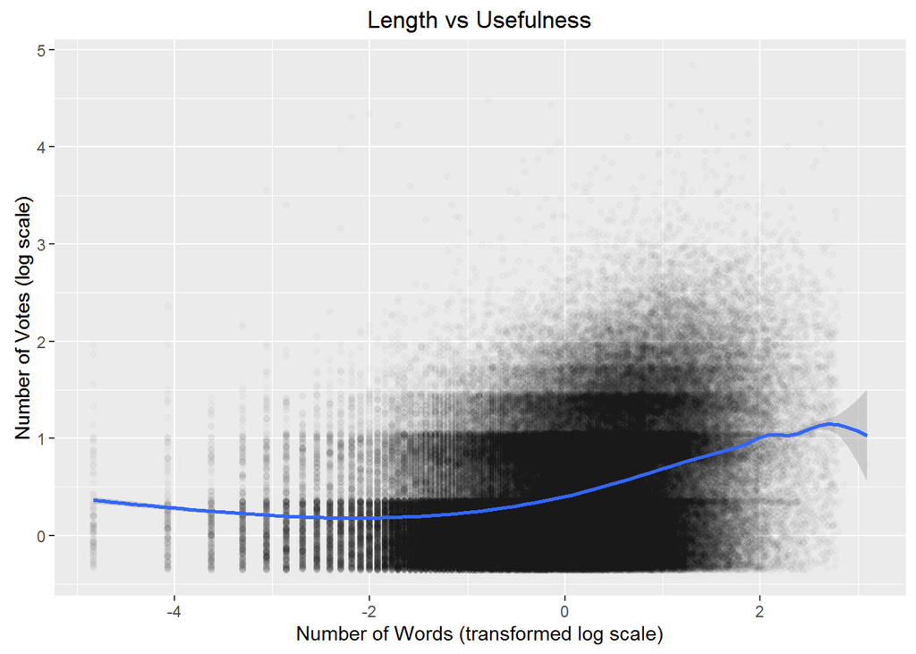

While the code is not included here, I attempted to predict the usefulness of the review from length, using a random forest to account for the non-linearity. This was able to explain about 11% of the variance in the number of useful votes. However, a simpler method is to try to predict the usefulness with a linear model, but with dummy variables for very short or very long reviews.

```
##
## Call:
## lm(formula = votes_useful ~ ., data = reviews_length)
##
## Residuals:
##     Min      1Q  Median      3Q     Max
## -1.1883 -0.4178 -0.1760  0.3696  4.0414
##
## Coefficients:
##              Estimate Std. Error t value Pr(>|t|)
## (Intercept)  0.435436   0.003320 131.161  < 2e-16 ***
## n_words      0.222471   0.001459 152.473  < 2e-16 ***
## stars1       0.040228   0.004493   8.954  < 2e-16 ***
## stars2       0.027351   0.005091   5.372 7.78e-08 ***
## stars4       0.022813   0.004019   5.677 1.38e-08 ***
## stars5      -0.027025   0.003840  -7.037 1.97e-12 ***
## under20      0.241593   0.005828  41.453  < 2e-16 ***
## over700      0.086196   0.019381   4.447 8.69e-06 ***
## ---
## Signif. codes:  0 '***' 0.001 '**' 0.01 '*' 0.05 '.' 0.1 ' ' 1
##
## Residual standard error: 0.5543 on 222512 degrees of freedom
## Multiple R-squared:  0.1186, Adjusted R-squared:  0.1186
## F-statistic:  4279 on 7 and 222512 DF,  p-value: < 2.2e-16
```

The linear model using such dummy variables works about as well as the random forest, with an adjusted R-squared of 0.118, so I based my model on this for the sake of simplicity. The question is whether it is possible to improve on this linear model. Attempting such an improvement, I constructed a text feature matrix using the quanteda R package, and then tried predicting the quality of the review from text features, together with the number of stars and the length of the review, using regularized linear regression. Since there are over 100,000 reviews in the training set, I only consider words that occurr in the reviews fairly often, choosing only those which have more than 800 occurrences in the training and test sets taken together.

```
##
##    ... lowercasing
##    ... tokenizing
##    ... indexing documents: 222,520 documents
##    ... indexing features: 139,620 feature types
##    ... created a 222520 x 139620 sparse dfm
##    ... complete.
## Elapsed time: 29.57 seconds.
```

The new model continues to assign a large amount of weight to the number of words, with a generally positive association between length and usefulness, but with a negative coefficient to the property of having more than 700 words, as we suspected from the plot of the length vs usefulness. This does not necessarily signify that long reviews are not useful, but merely that a correction is necessary in order to avoid putting too much weight on the length. We can look at the words most predictive of usefulness according to the model:

limo, ya, ass, yelpers, shit, won, dude…

Interestingly, some of the words which are most predictive of usefulness are quite negative in tone. This might be related to the fact that extremely negative reviews are rare, and consequently seem more informative. This is supported by the relatively high coefficient given to having only one star.

The correlation between the number of votes predicted by this model for the test set and the actual number of votes is .369, which implies that our model can explain 13.6% of the variance in the number of votes. This is only a modest improvement over the linear mode, but it is an actual improvement, not merely an apparent one, since we are getting this improvement while testing the model against new data.

Since the text feature matrix was created using the vocabulary from the entire set of reviews, I needed to do a bit more work in order to produce a method of creating predictions for entirely new reviews, outside the training and test sets. In essence it was necessary to count the number of times each feature occurs in the new text and then to apply the coefficients of the model to the results in order to produce the new predictions.

Applying this method to a new business from a third set of reviews (another five percent of Yelp’s dataset), visual inspection of the results in RStudio verifies that the model does a good of distinguishing somewhat useful reviews from useless reviews. However, it also indicates (as noted above) that this results largely from the length of the review.

In the example in question, we can look at the review that the model views as the most useful:

```
## 1. Some decent 'Que on my side of town! I'll admit, I had to check out this place
## after it was featured on "Diners, Drive-Ins, and Dives" on the Food Network.
## But without this tidbit, I might have never knew the place existed! Funniest
## thing about John Mull's is that it is basically located in the middle of
## residential homes. Yes! When you GPS the address you might think you're being
## led to the wrong place. But keep truckin' because the BBQ joint is on property
## of what looks to be a ranch house. John Mull's eating area shares the common
## space with what is essentially a butcher block. Get a whole cow, some eggs, and
## then a meal of BBQ afterwards? I don't see why not. While the market has been
## around for some time, my review basically goes over the BBQ station. It used to
## be just a shack when they first started, lately I hear they have a small food
## truck type deal to serve folks as well. They need the help, John Mull's can get
## busy for lunch! Typically it's take-out, but they do have a small seating area
## with about a dozen bench tables or so. If it's full, eat it out of your truck
## tailgate like most folks do! I am not an expert on BBQ by any means, but good
## food I can do. Sure, you have your naysayers that go on and on and on about
## how their BBQ sauce is from a bottle (I can confirm I think it is), but really
## I don't care. The meat itself is not artificially processed. Trimmed in-house,
## and smoked in-house! Flavor of the BBQ is what is necessary! John Mull's makes
## some mighty decent 'Que. Easiest thing on the menu to try if you're a noob to
## this place is just to go with a combo meal. A 2 Meat Combo will run you about
## $14, and a 3 Meat Combo will run about $16. When it's the wifey and I we usually
## opt for the 3 Meat Combo and share. Be careful, it's a lot of food! The 3 Meat
## Combo will easily feed a third person. Combos come with your choice of meats
## and sides. Meats include: -Hot Link -Brisket -Ribs -Pulled Pork -Pulled Chicken
## -1/4 Chicken Their strength lies in their ribs and brisket I think. I like their
## pulled pork, but if I'm having their ribs (which I always do) I compliment it
## with the brisket. The ribs are cooked just right, requisite pink ring around the
## outside, meat pulls off the bone (but not too easily), super moist and tender,
## finished on the grill with a slathering of BBQ sauce right before serving.
## The brisket is flavorful, and just plain juicy, thanks to the lovely fat cap
## that surrounds each one before smoking. OK, if you just say 'brisket' when you
## order your meat, you will most likely just get the lean end of the brisket.
## Which is not dry, but not as near darn tasty as the fatty end. So be specific
## on which part of brisket you want, lean or fat. I will usually ask for a 1/2
## portion of both. For sides, Road Kill Grill has some options too: -Potato or
## Macaroni Salad -Coleslaw -Baked Beans -Mac & Cheese -Green Beans Unfortunately,
## no collard greens or black eyed peas! But you can't have everything. I will
## mention that the green beans are just mainly reheated from the can, so I mainly
## skip that. The baked beans are very good, and their mac & cheese is actually
```

[output cut: 8 more lines]

```
## at Road Kill Grill is a sandwich. They load these suckers nicely so you get a
## nice portion of meat and sauce to bread. Basically a meal in itself! I enjoy
## the hot links sandwich in particular. This with extra hot BBQ sauce on top,
## and a side of coleslaw? Classic. BBQ can be a very picky topic, so you will see
## tons of varying reviews on John Mull's Meats & Road Kill Grill. This is because
## depending on what side of the country you are from, you have a different taste
## of what BBQ should be. Some like tomato based, some like vinegar based, some
## like mustard based, and so forth and so forth. Some folks like more smoke,
## some folks like less smoke, Hell, some folks like their BBQ baked in an oven
## instead. But no matter what, we all like good food. And I think Road Kill Grill
## overall has good food. Give them a try for yourself. You might like, but then
## again you might NOT like. Many reviews for this place are in the 3 or 4-star
## range, I tracked over to the 4-star area because I like it here. In a place like
## Las Vegas it's difficult to find good 'Que that's not from a place like Famous
## Dave's or Memphis Championship BBQ. Nuff' said.
```

And the two least useful:

```
## 1. Good Hot Links!
```

```
## 2. Great tasting food!
```

The difference is evident. Using Spearman’s rank-order correlation, I calculated a correlation of .41 between the ranking produced by the model and the actual votes.

```
##
##  Spearman's rank correlation rho
##
## data:  new_reviews$votes_useful and new_reviews$predictions
## S = 11841000, p-value < 2.2e-16
## alternative hypothesis: true rho is greater than 0
## sample estimates:
##       rho
## 0.4142524
```

This is somewhat higher than the average Spearman rank-order correlation over all businesses in the third set of reviews, which came to about .34.

```
## Average accuracy in rank ordering:  0.3369088
```

Overall, the model does improve on the simple linear model based on length, but not by much. However, there are suggestions in our results that yet more improvement is possible. For example, the model tends to put a high weight on words with a negative tone. This suggests that it might be possible to obtain better results by applying more sophisticated NLP methods, such as sentiment analysis.

This is a fairly common situation: most of the potential predictive power can be obtained fairly easily. Improvement is possible, but rapidly diminishing improvements require the application of rapidly increasing resources in terms of computing power, algorithmic complexity, and technical skill. In any particular case, one must determine to what degree it is worthwhile to apply these resources for the sake of the goal in question.